# **EA - case study resolution**

## Juan Julián Cea Morán

[figure not shown]

This presentation covers the completion of the technical test for the associate data scientist position at Electronic Arts (EA).

The objective is to carry out the steps of a datascience process with research load. Starting at the definition of the methodology to follow, the study of the data, the pre-processing of the data, the models implementation, the analysis of the results and the extraction of conclusions.

## Problem statement

- **Objective 1:** Create a document categorization classifier for the different contexts of the documents. You will be addressing this objective at context level, regardless of the language the documents are written in. Tasks/Requirements:
  - EDA: Exploratory data analysis of the Dataset.
  - Reproducibility/Methodology: The analysis you provide must be reproductible. Your analysis will fulfill the Data Science methodology.
  - Classification model: The deliverable will include a model which will receive a document as input and will output its class, which will be the context of that document.
- **Objective 2:** Perform a topic model analysis on the provided documents. You will discover the hidden topics and describe them. Tasks:
  - Profile the different documents and topics.
  - Provide a visualization of the profiles.

## Methodology

Once we have analyzed the problem, it's time to propose a methodology or work flow according to the data science classical life cycle.

[figure not shown]

# 1. Data Exploration

The first step in every data science and research project involves understanding the data. This is crucial because the rest of the processing pipeline will depend on how good this understanding is.

The data we are going to work with is a multilingual and multi-context set of documents that extracted from the following paper:

`Ferrero, Jérémy & Agnès, Frédéric & Besacier, Laurent & Schwab, Didier. (2016). A Multilingual, Multi-Style and Multi-Granularity Dataset for Cross-Language Textual Similarity Detection.` a

It is a multilingual and multi-context set of documents.

## Import data

```python
%%time
import pandas as pd
import os
from os import walk

docs_df = pd.DataFrame(columns=['Name', 'Text', 'Lang', 'Category'])

cat = None
lang = None
for root, dirs, files in os.walk("../data/documents_challenge/", topdown=True):
    for _dir in dirs:
        cat = _dir
        for root2, dirs2, files2 in os.walk(os.path.join(root, _dir)):
            for _dir2 in dirs2:
                lang = _dir2
                for root3, dirs3, files3 in os.walk(os.path.join(root2, _dir2)):
                    for file in files3:
                        f = open(os.path.join(root3, file), 'r', encoding='utf-8')
                        docs_df.loc[docs_df.shape[0]] = [file, f.read(), lang, cat]
                        f.close()

    break
```

```
Wall time: 1min 19s
```

```python
docs_df.head()
```

|  | Name | Text | Lang | Category |
| --- | --- | --- | --- | --- |
| 0 | apr-book-0-en.txt | i read this book because in my town, everyone ... | en | APR |
| 1 | apr-book-1-en.txt | recipes appreciated by the family (small and l... | en | APR |
| 2 | apr-book-10-en.txt | i say no to ease ..... and not to the author w... | en | APR |
| 3 | apr-book-100-en.txt | milady has found a good vein: anita blake. bas... | en | APR |
| 4 | apr-book-1000-en.txt | 460 bc, somewhere in greece: "gentlemen, i dec... | en | APR |

## Dataset information

First of all, let's explore our dataset after imort all documents. It will be interesting to check some parameters in order to understand the organization of the samples in the corpus.

- Let's check length, number of different categories and number of languages.
- Find null values in data.
- Check data usage.
- Check duplicates.
- Remove meaningless samples.

```python
print('Longitud: ' + str(len(docs_df)) + " samples")
print('Categories: ' + ', '.join(docs_df['Category'].unique()))
print('Languages: ' + ', '.join(docs_df['Lang'].unique()) + '\n')
```

```
Longitud: 23128 samples
Categories: APR, Conference_papers, PAN11, Wikipedia
Languages: en, fr, es
```

```python
docs_df.info()
```

```
<class 'pandas.core.frame.DataFrame'>
Int64Index: 23128 entries, 0 to 23127
Data columns (total 4 columns):
 #   Column    Non-Null Count  Dtype
---  ------    --------------  -----
 0   Name      23128 non-null  object
 1   Text      23128 non-null  object
 2   Lang      23128 non-null  object
 3   Category  23128 non-null  object
dtypes: object(4)
memory usage: 903.4+ KB
```

```python
docs_df.describe()
```

|  | Name | Text | Lang | Category |
| --- | --- | --- | --- | --- |
| count | 23128 | 23128 | 23128 | 23128 |
| unique | 23128 | 23012 | 3 | 4 |
| top | pan-92-12-es.txt | translation not available | en | Wikipedia |
| freq | 1 | 13 | 9724 | 13588 |

```python
docs_df[docs_df.duplicated(subset=('Text'), keep='first')]
```

|  | Name | Text | Lang | Category |
| --- | --- | --- | --- | --- |
| 132 | apr-book-1192-en.txt | translation not available | en | APR |
| 319 | apr-book-1472-en.txt | disappointed by flaubert, it is somewhat prete... | en | APR |
| 370 | apr-book-1550-en.txt | if you want an opinion on evolution, it is rea... | en | APR |
| 404 | apr-book-1600-en.txt | what a disappointment. the awards received by ... | en | APR |
| 638 | apr-book-1952-en.txt | they told me 'you see, it's great, there's no ... | en | APR |
| ... | ... | ... | ... | ... |
| 8233 | pan-75-0-en.txt | Metebaza! ... Fea! ... Feona! ... Chula! ...\... | en | PAN11 |
| 8897 | pan-228-6-es.txt | Volvió a los dos meses, muerto de hambre, mal... | es | PAN11 |
| 9148 | pan-285-3-es.txt | (N. de la E.)\n\n[32] Nochebuena chiquita, as... | es | PAN11 |
| 9410 | pan-63-3-es.txt | La hermosa canción, que canta Margarita mientr... | es | PAN11 |
| 9427 | pan-68-14-es.txt | Otro elemento se reitera igualmente en sus no... | es | PAN11 |

116 rows × 4 columns

## Get some insights

Now is time to study the data so we can learn from it before making any further step. There are several metrics to look at, but for this study case we are going to plot two of them.

- Data distribution over the corpus.
- Terms with more occurrences over the corpus using wordclouds.

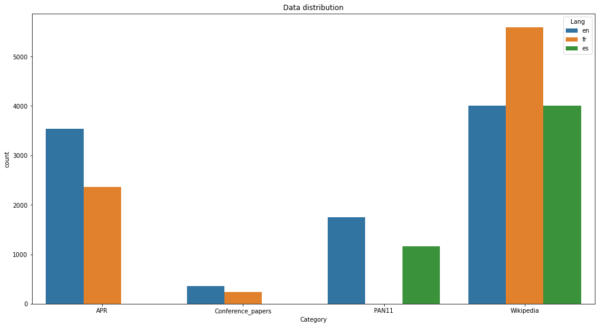

```python
import matplotlib.pyplot as plt
%matplotlib inline

import seaborn as sns

plt.figure(figsize=(17,9));
sns.countplot(x="Category", hue="Lang", data=docs_df);
plt.title("Data distribution");
```

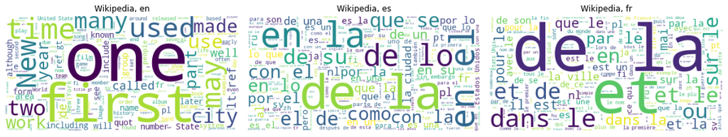

```python
import wordcloud
from wordcloud import WordCloud

import matplotlib.pyplot as plt
%matplotlib inline

idx = 0

fig = plt.figure(figsize=(15, 15))

#for cat in docs_df['Category'].unique():
cat = "Wikipedia"
aux = docs_df[docs_df['Category'] == cat]
for lang in aux['Lang'].unique():
    texts = aux[aux['Lang'] == lang]['Text']

    wordcloud = WordCloud(background_color="white").generate(' '.join(texts))

    idx += 1

    plt.subplot(3, 3, idx)
    plt.title(f"{cat}, {lang}")
    plt.imshow(wordcloud)
    plt.axis('off')

fig.tight_layout()
```

# 2. Text Preprocessing

[figure not shown]

- We are working with text in 3 possible languages: english, spanish and french.
- We have no indication that the final system can work with more languages, so we will only focus on those three.
- Necessary to apply textual pre-processing adapted to each of the different languages present in the dataset.

## Language identification

There are some python libraries that address this issue. For example:

- LangID: Developped by Lui Marco, is a standalone Language Identification (LangID) tool bassed on previous researchs by the authors. https://github.com/saffsd/langid.py
- langdetect: Port of Nakatani Shuyo's language-detection library (version from 03/03/2014) to Python. https://github.com/Mimino666/langdetect
- TextBlob: A popular Text Processing package for Python. It includes a module for language detection based on a Google API. Requires Internet conection. https://textblob.readthedocs.io/en/dev/

Let's compare them!

```python
# Let's take text in the 3 languages
en = lang_df.loc[(lang_df['Lang'] == 'en')][0:100]
es = lang_df.loc[(lang_df['Lang'] == 'es')][0:100]
fr = lang_df.loc[(lang_df['Lang'] == 'fr')][0:100]

sample_texts = pd.concat([en, es, fr])
```

```python
import langid
from langdetect import detect
from textblob import TextBlob

_textblob = [TextBlob(l).detect_language() for l in sample_texts['Text']]
_langdetect = [l for l in sample_texts['Text'].apply(langdetect.detect)]
_langid = [l [0] for l in sample_texts['Text'].apply(langid.classify)]
```

```python
langid_error =  0
langdetect_error = 0
textblob_error = 0

sample_texts_lang = [s for s in sample_texts['Lang']]

for i in range(0, len(sample_texts_lang)):
    if _langid[i] != sample_texts_lang[i]:
        langid_error += 1
    if _langdetect[i] != sample_texts_lang[i]:
        langdetect_error += 1
    if _textblob[i] != sample_texts_lang[i]:
        textblob_error += 1

print('LangID Error:', langid_error)
print('LangDetect Error:', langdetect_error)
print('TextBlob Error:', textblob_error)
```

```
LangID Error: 0
LangDetect Error: 1
TextBlob Error: 0
```

```python
full_langid = [l [0] for l in lang_df['Text'].apply(langid.classify)]
```

```python
error = 0

full_langs = [s for s in lang_df['Lang']]

for i in range(0, len(full_langs)):
    if full_langid[i] != full_langs[i]:
        error += 1

print(error)
```

```
1656
```

## Cleaning and tokenize

This process is crucial, as it will lay the foundation for all the other steps in the project. As we can't use language identification system, let's make a custom function that preprocess any text regardless the language it is writed on.

This involves performing a set of transformations on each text example:

- **1.** A unidecode will be applied in order to remove the accents.
- **2.** The text will be converted to lowercase.
- **3.** At this point, different regular expressions will be applied to filter out urls, html information,etc.
- **4.** Remove non alphabetic characters like numbers.
- **5.** Divide the text in tokens separating it by spaces and discarding stopwords (very common words that do not provide semantic information for this task).
- **6.** Remove words with less than 3 characters.

```python
stopwords = stopwords.words("french") + stopwords.words("english") + stopwords.words("spanish")

def preprocess(text):
    text = unidecode.unidecode(text.strip().lower())

    url_regex = re.compile('http[s]?://(?:[a-zA-Z]|[0-9]|[$-_@.&+]|[!*\(\),]|(?:%[0-9a-fA-F][0-9a-fA-F]))+')
    text = url_regex.sub(' ', text)

    html_pattern = re.compile('<.?>|&([a-z0-9]+|#[0-9]{1,6}|#x[0-9a-f]{1,6});')
    text =  html_pattern.sub(' ', text)

    chars_regex = re.compile('[^a-zA-Z0-9 -]')
    text = chars_regex.sub(' ', text)

    number_regex = re.compile('[\d]+')
    text = number_regex.sub(' ', text)

    text = ' '.join(text.split('\''))

    text = word_tokenize(text)

    text = [word for word in text if word not in stopwords and len(word)>2]

    return text
```

```python
docs_df.head()
```

|  | Name | Text | Preprocessed | Lang | Category |
| --- | --- | --- | --- | --- | --- |
| 0 | apr-book-0-en.txt | i read this book because in my town, everyone ... | [read, book, town, everyone, uses, order, phar... | en | APR |
| 1 | apr-book-1-en.txt | recipes appreciated by the family (small and l... | [recipes, appreciated, family, small, large, r... | en | APR |
| 2 | apr-book-10-en.txt | i say no to ease ..... and not to the author w... | [say, ease, author, even, made, effort, meet, ... | en | APR |
| 3 | apr-book-100-en.txt | milady has found a good vein: anita blake. bas... | [milady, found, good, vein, anita, blake, base... | en | APR |
| 4 | apr-book-1000-en.txt | 460 bc, somewhere in greece: "gentlemen, i dec... | [somewhere, greece, gentlemen, decided, visit,... | en | APR |

## Explore results

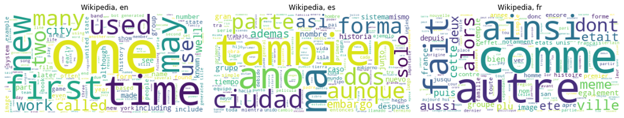

```python
from wordcloud import WordCloud

import matplotlib.pyplot as plt
%matplotlib inline

idx = 0

fig = plt.figure(figsize=(15, 15))

# for cat in docs_df['Category'].unique():
cat = "Wikipedia"
aux = docs_df[docs_df['Category'] == cat]
for lang in aux['Lang'].unique():
    texts = aux[aux['Lang'] == lang]['Preprocessed'].apply(' '.join).tolist()

    wordcloud = WordCloud(background_color="white").generate(' '.join(texts))

    idx += 1

    plt.subplot(3, 3, idx)
    plt.title(f"{cat}, {lang}")
    plt.imshow(wordcloud)
    plt.axis('off')

fig.tight_layout()
```

# 3. Classification

Once we have normalized and tokenied the corpus, our data is ready to be used by Machine Learning models. In this case, the required task is a supervised classification problem, since we have pre-labeled data to work with.

To addres this problem, we will be using classifiers like Multinomial Naive Bayes or Support Vector Machine.

But, before feeding the data into the models, let's prepare the datasets.

## Prepare datasets

We have to create train and test dataset, so we have to split our dataset. But before do that, there are some operations that we need to perform.

- First of all, we have to encode the categories into diferent numeric labels, conforming the targets that our model will try to predict.
- Then we have to randomly shuffle al data samples, so the distribution of categories and languages over the train - test partitions will be as even as possible.
- Lastly, we create train-test partitions so the model can be trained and tested on unseen data.

```python
from sklearn import preprocessing

le = preprocessing.LabelEncoder()
preproc_df['Target'] = le.fit_transform([cat for cat in preproc_df['Category']])

print(dict(zip(le.classes_, le.transform(le.classes_))))
```

```
{'APR': 0, 'Conference_papers': 1, 'PAN11': 2, 'Wikipedia': 3}
```

```python
preproc_df = preproc_df.sample(frac=1).reset_index(drop=True)

preproc_df.head()
```

|  | Preprocessed | Lang | Category | Target |
| --- | --- | --- | --- | --- |
| 0 | [arquitecto, rob, schuurman, sjoerd, soeters, ... | es | Wikipedia | 3 |
| 1 | [saint-exupery, realise, travers, histoire, pe... | fr | APR | 0 |
| 2 | [automation, consiste, utiliser, services, log... | fr | Wikipedia | 3 |
| 3 | [varron, marcus, terentius, varro, ecrivain, s... | fr | Wikipedia | 3 |
| 4 | [flavius, julius, constans, roman, emperor, ru... | en | Wikipedia | 3 |

```python
from sklearn.model_selection import train_test_split

train_df, test_df = train_test_split(preproc_df, test_size=0.1)
```

## Vectorize texts

The next step is to vectorize the extracted features (text tokens). Our Machine Learning models are not able to work with strings, so we need to convert those strings into numbers.

To do that, there are different approaches, but for the pourpose of this case study, we are going to use TF-IDF vectorizer:

- **TF**: Or **Term Frequency**, is an indicator of how many times a given term occurs in a certain document.
- **IDF**: Or **Inverse Document Frequency**, give us an indication of how important is each one of the terms within the whole corpus of documents.

```python
%%time
from sklearn.feature_extraction.text import TfidfVectorizer

tfidf_vect = TfidfVectorizer(use_idf=True, min_df=12)
X_train = tfidf_vect.fit_transform([' '.join(text) for text in X_train])
X_test = tfidf_vect.transform([' '.join(text) for text in X_test])
```

```
Wall time: 12.8 s
```

## Multinomial Naive Bayes

Let's start testing a MultinomialNB for classify our data. This classifier is suitable for text classification, since it is intended to be used with discrete features like word counts.

First, we have to train the model using the training data.

```python
%%time
from sklearn.naive_bayes import MultinomialNB

clf = MultinomialNB()
clf.fit(X_train, Y_train)
```

```
Wall time: 71.8 ms
```

```
MultinomialNB()
```

```python
Y_pred = clf.predict(X_test)
```

```python
from sklearn import metrics

print('Accuracy MultinomialNB: ' + "%.2f" % round(100 * metrics.accuracy_score(Y_test, Y_pred), 2) + '%')
```

[output not shown]

[figure not shown]

```python
print_confusion_matrix(conf, labels);
```

## Linear Support Vector Machine

This also a good algorithm for supervised learning tasks. I'm going to test scikit-learn implementation.

Again, we have to train the model using the training data.

```python
%%time
from sklearn.svm import LinearSVC

clf = LinearSVC()
clf.fit(X_train, Y_train)
```

```
Wall time: 986 ms
```

```
LinearSVC()
```

```python
%%time
Y_pred = clf.predict(X_test)
```

```
Wall time: 8.97 ms
```

```python
from sklearn import metrics

print('Accuracy Support Vector Machine: ' + "%.2f" % round(100 * metrics.accuracy_score(Y_test, Y_pred), 2) + '%')
```

```
Accuracy Support Vector Machine: 98.74%
```

[figure not shown]

```python
print_confusion_matrix(conf, labels);
```

## Final design

```python
from sklearn.pipeline import Pipeline
from sklearn.feature_extraction.text import TfidfVectorizer
from sklearn.svm import LinearSVC

pipe = Pipeline([
    ('vect', TfidfVectorizer(min_df=12, tokenizer=None)),
    ('clf', LinearSVC())
])
```

```python
wiki_doraemon = """
Doraemon (Japanese: ドラえもん Japanese pronunciation: [do̞ɾa̠e̞mõ̞ɴ]) is a Japanese manga series written and illustrated by Fujiko Fujio, the pen name of the duo Hiroshi Fujimoto and Motoo Abiko. The series has also been adapted into a successful anime series and media franchise. The story revolves around an earless robotic cat named Doraemon, who travels back in time from the 22nd century to aid a boy named Nobita Nobi (野比のび太, Nobi Nobita).

The first full story in the Doraemon manga series was published in January 1970. A pre-advertisement for the manga was published in six different magazines in December 1969. A total of 1,465 stories were created in the original series, which are published by Shogakukan. It is one of the best-selling manga in the world, and has sold over 100 million copies as of 2015.

The volumes are collected in the Takaoka Central Library in Toyama, Japan, where Fujiko Fujio was born. Turner Broadcasting System bought the rights to the Doraemon anime series in the mid-1980s for an English-language release in the United States,[3] but cancelled it without explanation before broadcasting any episodes. In July 2013, Voyager Japan announced the manga would be released digitally in English via the Amazon Kindle e-book service.

The Foreign Ministry action confirms that Doraemon has come to be considered a Japanese cultural icon. In India, its Hindi, Telugu and Tamil translation has been telecasted, where the anime version is the highest-rated kids' show; winning the Best Show For Kids award twice at the Nickelodeon Kids' Choice Awards India in 2013 and 2015. In 2002 Time Asia magazine acclaimed the character as an "Asian Hero" in a special feature survey. An edited English dub distributed by TV Asahi aired on Disney XD in the United States started on July 7, 2014. On August 17, 2015, another English dubbed version distributed by Luk Internacional began broadcasting on Boomerang UK. The film series is the largest by number of admissions in Japan.
"""
```

```python
labels[pipe.predict(preprocess(text_doraemon))[0]]
```

```
'Wikipedia'
```

# 4. Topic Modeling

Topic Modeling is a classic task in NLP field consisting on discovering abstract topics hidden in the data corpus. This is usefull for example, to understand our data or when we want to make unsupervised classification tasks.

- The first approach would be to carry out a study of topics for each language present in each of the 4 contexts.
- The other option consists of carrying out Topic Modeling for each context without taking into account the different languages.

If choosing the second option, certain key points must be taken into account for its correct implementation. The main problem to solve is to be able to represent words from different languages in the same vector space so that they are related to each other independently of the language but according to the context.

## Different Approaches

There are different approaches to accomplish Topic Modeling. It's worth to spend some time reviewing those options in order to choose an appropriate one.

- **Bag of Words + LDA/NMF/LSI/etc**
- **Word embeddings**

The first approach is not aligible for multilingual topic modeling, so we shoud make a model for each language and each context. However, there are several extensions to the classic LDA for addressing multilingual topic modeling. They can be seen in this review: http://papers.nips.cc/paper/4583-symmetric-correspondence-topic-models-for-multilingual-text-analysis.pdf .Nevertheless, there is no implementantion, so let's save this for future work.

Regardding the second option, there are some proposals applicable to multilingual data called **multilingual word embeddings**: https://www.aclweb.org/anthology/D18-1024/ and https://github.com/facebookresearch/MUSE As well as the LDA extensions, this solution will be addressed in future iterations.

## Implementing LDA with language dependence

As I said before, the most straight forward solution consist on performing LDA for each category and each language independently. LDA (*Latent Dirichlet Allocation*) is an unsupervised dimensionality recduction algorithm that considers each document in the corpus as a mix of hidden topics and each one of this topic, as a mix of keywords.

For the pourpose of this presentation, let's perform Topic Modeling over Wikipedia texts in both English and Spanish

### 1. English

```python
%%time
from gensim import corpora, models

id2word = corpora.Dictionary(wiki_en_data)
id2word.filter_extremes(no_below=12)
corpus = [id2word.doc2bow(sample) for sample in wiki_en_data]
```

```
Wall time: 7.4 s
```

```python
%%time
num_topics = 6

lda_model = models.LdaModel(corpus, num_topics, id2word=id2word, passes=4)
```

```
Wall time: 1min 37s
```

```python
%matplotlib inline
import pyLDAvis
import pyLDAvis.gensim

vis = pyLDAvis.gensim.prepare(topic_model=lda_model, corpus=corpus, dictionary=id2word)
pyLDAvis.enable_notebook()
pyLDAvis.display(vis)
```

[interactive chart not shown]

### 2. Spanish

```python
%%time
from gensim import corpora, models

id2word = corpora.Dictionary(wiki_es_data)
id2word.filter_extremes(no_below=12)
corpus = [id2word.doc2bow(sample) for sample in wiki_es_data]
```

```
Wall time: 8.86 s
```

```python
%%time
num_topics = 7

lda_model = models.LdaModel(corpus, num_topics, id2word=id2word, passes=4)
```

```
Wall time: 1min
```

```python
%matplotlib inline
import pyLDAvis
import pyLDAvis.gensim

vis = pyLDAvis.gensim.prepare(topic_model=lda_model, corpus=corpus, dictionary=id2word)
pyLDAvis.enable_notebook()
pyLDAvis.display(vis)
```

[interactive chart not shown]

# 5. Conclusions

After being worked on the problem, there are some conclusions that we should extract.

### Future Work

- Improve topic modeling results.
- Research differences between BoW + LDA and Word Embeddings
- Research Multi Lingual Topic Modeling with LDA alternatives and Multilingual WE.